# Part II - (L'effet de l'age, du type d'utilisateur et de l'heure de debut sur la durée des trajets à vélo)

## by (Aboubacar)

> **Before you start**: You must have the README.md file ready that include a summary of main findings that reflects on the steps taken during the data exploration (Part I notebook). The README.md file should also describes the key insights that will be conveyed by the explanatory slide deck (Part II outcome)

## Investigation Overview

> cet ensemble de données comprend des informations sur les trajets individuels effectués dans un système de partage de vélos couvrant la grande région de la baie de San Francisco.Il est contenu dans un fichier 201902-fordgobike-tripdata.csvtéléchargé depuis https://video.udacity-data.com/topher/2020/October/5f91cf38_201902-fordgobike-tripdata/201902-fordgobike-tripdata.csv.

Après explorations préable de l'ensemble de données, nous sommes arriver à quelques conclusion notamment comment l'age et l'heure de debut affecte la durée du trajet. Voyons cela de plus près

Nous allons cependant nous focaliser principalement dans cette partie sur les variables suivantes : l'age et l'heure de debut et la durée

> **Rubric Tip**: The key insights in the slideshow must match those documented in the README.md summary.

## Dataset Overview

```python
# import all packages and set plots to be embedded inline
import numpy as np
import pandas as pd
import matplotlib.pyplot as plt
import seaborn as sb

%matplotlib inline

# suppress warnings from final output
import warnings
warnings.simplefilter("ignore")
```

> Note that the above cells have been set as "Skip"-type slides. That means that when the notebook is rendered as http slides, those cells won't show up.

## Repartition des utilisateurs en fonction du genre

> Via ce visuel on verra le genre qui fait le plus du velo

> **Rubric Tip**: Provide at least 3 **polished** visualizations to convey key insights. The total number of visualizations in the slideshow shoould be less than 50% of the number of visualizations in the exploratory analysis. For example, if the exploratory analysis (Part I) has 18 visualizations, the slideshow can have (3 - 8) visualizations.

> **Rubric Tip**: Each visualization in the slideshow is associated with **descriptive comments** that accurately depict their purpose and your observation.

> **Rubric Tip**: All plots in the slideshow are appropriate, meaning the plot type, encodings, and transformations are suitable to the underlying data.

> **Rubric Tip**: All plots in the slideshow are polished, meaning all plots have a title, labeled x/y axes (with units), x/y ticks, and legends.

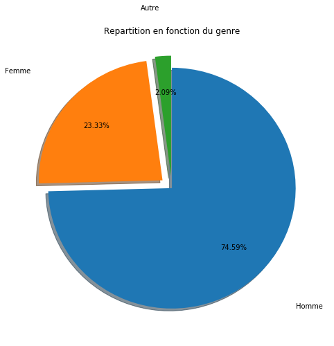

```python
plt.figure(figsize=(8,8))
Gender_counts = df['member_gender'].value_counts()

plt.pie(Gender_counts, labels = ['Homme','Femme','Autre'], startangle = 90,explode =(0 , 0.1, 0.1)  ,
        counterclock = False,autopct = lambda x: str(round(x, 2)) + '%',
           pctdistance = 0.7, labeldistance = 1.4,
           shadow = True);
plt.title("Repartition en fonction du genre");
```

74,59 % des utilisateurs sont des hommes, suivi de 23,33 % de femmes Les autres utilisateurs sont en nombre infime voir 2,09 %

## Âge et durée du voyage pour chaque type d'utilisateur

> You should have at least three visualizations in your presentation, but feel free to add more if you'd like!

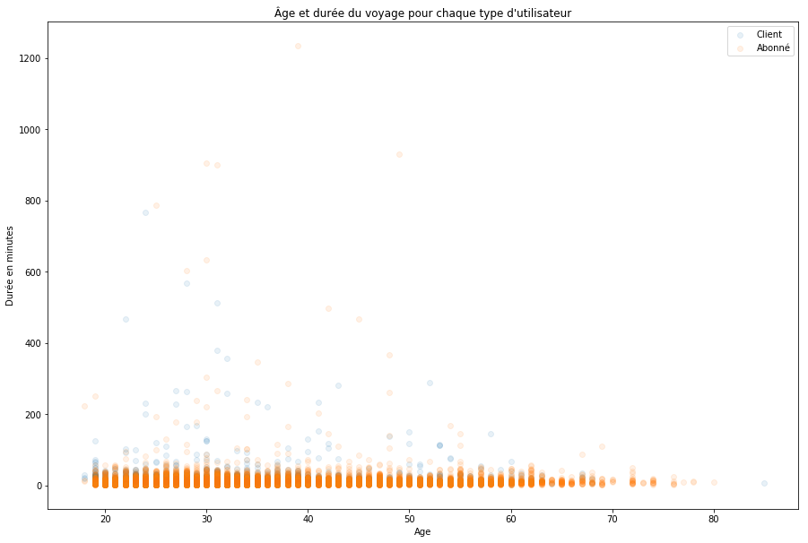

```python
df1 = df.sample(20000, random_state=1)

plt.figure(figsize = [15, 10]);
user_type_markers = [['Customer', 'o'],
               ['Subscriber', 'x']]

for cat, marker in user_type_markers:
    df_cat = df1[df1['user_type'] == cat]
    plt.scatter(data = df_cat, x = 'Age', y = 'duration_min', alpha=2/20);
plt.legend(['Client','Abonné']);
plt.xlabel('Age');
plt.ylabel('Durée en minutes');
plt.title("Âge et durée du voyage pour chaque type d'utilisateur");
```

- La majorité des utilisateurs plus âgés sont des abonnés et passent peu de temps dans leurs trajets à vélo.
- La durée des trajets des jeunes clients est légèrement supérieure à celle des abonnés plus jeunes.

## heure de début, durée et type d'utilisateur

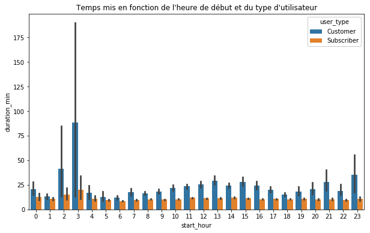

```python
plt.figure(figsize=[10,6])
ax = sb.barplot(data = df, x = 'start_hour', y = 'duration_min', hue = 'user_type')
ax.legend(loc = 1, framealpha = 1, title = 'user_type')
plt.title("Temps mis en fonction de l'heure de début et du type d'utilisateur");
```

- Les clients durent plus que les abonnés.
- Entre 2 heures du matin, 3 heures du matin la durée du vélo est plus longue que n'importe quelle heure

### Generate Slideshow

Once you're ready to generate your slideshow, use the `jupyter nbconvert` command to generate the HTML slide show.

```python
# Use this command if you are running this file in local
!jupyter nbconvert Part_II_fordgobike-trip.ipynb --to slides --post serve --no-input --no-prompt
```

> In the classroom workspace, the generated HTML slideshow will be placed in the home folder.

> In local machines, the command above should open a tab in your web browser where you can scroll through your presentation. Sub-slides can be accessed by pressing 'down' when viewing its parent slide. Make sure you remove all of the quote-formatted guide notes like this one before you finish your presentation! At last, you can stop the Kernel.

### Submission

If you are using classroom workspace, you can choose from the following two ways of submission:

1. **Submit from the workspace**. Make sure you have removed the example project from the /home/workspace directory. You must submit the following files:
   - Part_I_notebook.ipynb
   - Part_I_notebook.html or pdf
   - Part_II_notebook.ipynb
   - Part_I_slides.html
   - README.md
   - dataset (optional)
1. **Submit a zip file on the last page of this project lesson**. In this case, open the Jupyter terminal and run the command below to generate a ZIP file.

   ```
   zip -r my_project.zip .
   ```

   The command abobve will ZIP every file present in your /home/workspace directory. Next, you can download the zip to your local, and follow the instructions on the last page of this project lesson.